# Rental Pricing Data Analysis

# Rental Pricing Trend within Klang Valley

Dataset was taken from Kaggle, webscraped from Mudah.com by a public user. This project aims to provide visual insights on the trend of monthly rent with given category (provided in Mudah website) such as location, size, number of bedrooms, parking or furnished. This dataset is chosen as I am also actively looking for a new unit to move in Klang Valley. Therefore having this insights will hopefully help me compare my options and choices that I already had, to compare it within the actual market trend.

### Installing data packages and library

```r
options(repos = "https://cloud.r-project.org")
```

```r
install.packages("stringr")
library(stringr)
```

```r
install.packages("ggplot2")
library(ggplot2)
install.packages("tidyverse")
library(tidyverse)
install.packages("dplyr")
library(dplyr)
library(readr)
```

```r
rental_df = read.csv("Rental Pricing.csv")
```

### Data Exploration

To describe the whole dataset (rows and columns), also checking on how many empty cells are within the dataset.

```r
colnames(rental_df)
```

```
##  [1] "ads_id"                "property_type"         "prop_name"
##  [4] "completion_year"       "monthly_rent"          "district"
##  [7] "parking"               "bathroom"              "size"
## [10] "furnished"             "facilities"            "additional_facilities"
## [13] "region"
```

```r
str(rental_df)
```

```
## 'data.frame':    19991 obs. of  13 variables:
##  $ ads_id               : int  100323185 100203973 100323128 100191767 97022692 100322897 100322962 100322885 100322866 100322863 ...
##  $ property_type        : chr  "Condominium" "Condominium" "Apartment" "Apartment" ...
##  $ prop_name            : chr  "The Hipster @ Taman Desa" "Segar Courts" "Pangsapuri Teratak Muhibbah 2" "Sentul Point Suite Apartment" ...
##  $ completion_year      : int  2022 NA NA 2020 NA NA NA 2018 2014 NA ...
##  $ monthly_rent         : num  4200 2300 1000 1700 1299 ...
##  $ district             : chr  " Taman Desa" " Cheras" " Taman Desa" " Sentul" ...
##  $ parking              : int  2 1 NA 1 1 1 2 1 1 1 ...
##  $ bathroom             : int  6 2 2 2 1 2 2 1 1 2 ...
##  $ size                 : int  1842 1170 650 743 494 884 982 700 750 862 ...
##  $ furnished            : chr  "Fully Furnished" "Partially Furnished" "Fully Furnished" "Partially Furnished" ...
##  $ facilities           : chr  "Minimart, Gymnasium, Security, Playground, Swimming Pool, Parking, Lift, Barbeque area, Multipurpose hall, Jogging Track" "Playground, Parking, Barbeque area, Security, Jogging Track, Swimming Pool, Gymnasium, Lift, Sauna" "Minimart, Jogging Track, Lift, Swimming P…
##  $ additional_facilities: chr  "Air-Cond, Cooking Allowed, Washing Machine" "Air-Cond, Cooking Allowed, Near KTM/LRT" "" "Cooking Allowed, Near KTM/LRT, Washing Machine" ...
##  $ region               : chr  "Kuala Lumpur" "Kuala Lumpur" "Kuala Lumpur" "Kuala Lumpur" ...
```

```r
head(rental_df)
```

|  | ads_id | property_type | prop_name | completion_year | monthly_rent | district | parking | bathroom | size | furnished | facilities | additional_facilities | region |
| --- | --- | --- | --- | --- | --- | --- | --- | --- | --- | --- | --- | --- | --- |
| 1 | 100323185 | Condominium | The Hipster @ Taman Desa | 2022 | 4200 | Taman Desa | 2 | 6 | 1842 | Fully Furnished | Minimart, Gymnasium, Security, Playground, Swimming Pool, Parking, Lift, Barbeque area, Multipurpose hall, Jogging Track | Air-Cond, Cooking Allowed, Washing Machine | Kuala Lumpur |
| 2 | 100203973 | Condominium | Segar Courts | NA | 2300 | Cheras | 1 | 2 | 1170 | Partially Furnished | Playground, Parking, Barbeque area, Security, Jogging Track, Swimming Pool, Gymnasium, Lift, Sauna | Air-Cond, Cooking Allowed, Near KTM/LRT | Kuala Lumpur |
| 3 | 100323128 | Apartment | Pangsapuri Teratak Muhibbah 2 | NA | 1000 | Taman Desa | NA | 2 | 650 | Fully Furnished | Minimart, Jogging Track, Lift, Swimming Pool |  | Kuala Lumpur |
| 4 | 100191767 | Apartment | Sentul Point Suite Apartment | 2020 | 1700 | Sentul | 1 | 2 | 743 | Partially Furnished | Parking, Playground, Swimming Pool, Squash Court, Security, Minimart, Gymnasium, Lift | Cooking Allowed, Near KTM/LRT, Washing Machine | Kuala Lumpur |
| 5 | 97022692 | Service Residence | Arte Mont Kiara | NA | 1299 | Mont Kiara | 1 | 1 | 494 | Not Furnished | Parking, Security, Lift, Swimming Pool, Playground, Gymnasium, Barbeque area, Minimart, Multipurpose hall, Club house, Jogging Track | Air-Cond | Kuala Lumpur |
| 6 | 100322897 | Apartment | Residensi Vista Wirajaya | NA | 1500 | Setapak | 1 | 2 | 884 | Partially Furnished | Parking, Security, Lift, Swimming Pool, Playground, Multipurpose hall | Cooking Allowed, Near KTM/LRT | Kuala Lumpur |

```r
emptycell = colSums(is.na(rental_df))
print(emptycell)
```

```
##                ads_id         property_type             prop_name
##                     0                     0                     0
##       completion_year          monthly_rent              district
##                  9185                     2                     0
##               parking              bathroom                  size
##                  5702                     6                     0
##             furnished            facilities additional_facilities
##                     0                     0                     0
##                region
##                     0
```

Dataset is already good as it is. Empty cells in column ‘parking’ and ‘completion_year’ will be ignored as it will not be used as much in the upcoming analysis

### Data Preparation

Checking for numerical outliers in the dataset; size and monthly rent. Plotting graph with outliers will make our plots skewed.

```r
#ggplot(data = rental_df) +
  #geom_point(mapping = aes(x = size, y = monthly_rent, color = property_type)) +
  #labs(title = "Plotted chart with presence of outliers")
```

```r
rentsummary = summary(rental_df$monthly_rent)
q1 = rentsummary["1st Qu."]
median = rentsummary['Median']
q3 = rentsummary["3rd Qu."]

lower_limit = q1 - 1.5 * IQR(rental_df$monthly_rent, na.rm = TRUE)
upper_limit = q3 + 1.5 * IQR(rental_df$monthly_rent, na.rm = TRUE)


print(lower_limit)
```

```
## 1st Qu.
##      50
```

```r
print(upper_limit)
```

```
## 3rd Qu.
##    2850
```

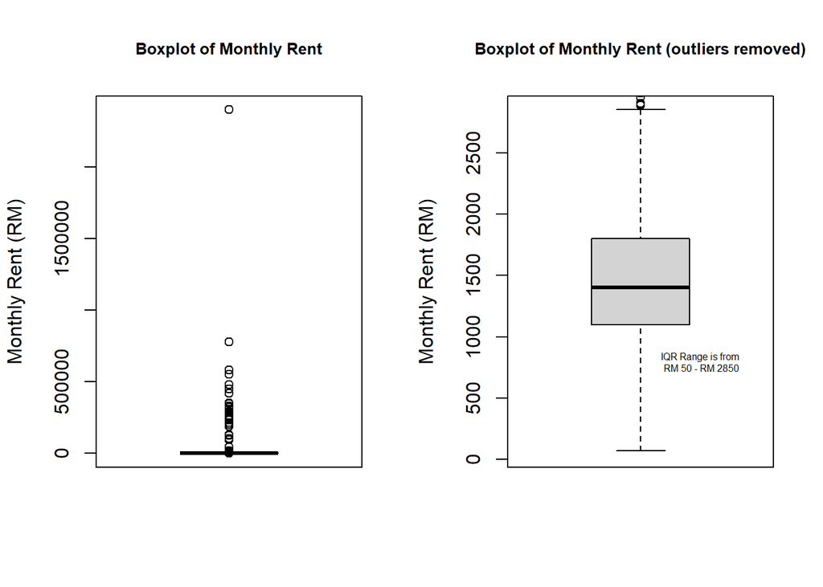

```r
par(mfrow = c(1, 2))
boxplot(rental_df$monthly_rent, main = "Boxplot of Monthly Rent", ylab = "Monthly Rent (RM)", cex.main = 0.8)
boxplot(rental_df$monthly_rent, main = "Boxplot of Monthly Rent (outliers removed)", ylab = "Monthly Rent (RM)", ylim = c(lower_limit, upper_limit), cex.main = 0.8)
text(x = 1.25, y = 800, labels = "IQR Range is from \nRM 50 - RM 2850", cex = 0.5)
```

```r
sizesummary = summary(rental_df$size)
q1_size = sizesummary["1st Qu."]
median_size = sizesummary['Median']
q3_size = sizesummary["3rd Qu."]

size_lowerlimit = q1 - 1.5 * IQR(rental_df$size, na.rm = TRUE)
size_upperlimit = q3 + 1.5 * IQR(rental_df$size, na.rm = TRUE)


print(size_lowerlimit)
```

```
## 1st Qu.
##     659
```

```r
print(size_upperlimit)
```

```
## 3rd Qu.
##    2241
```

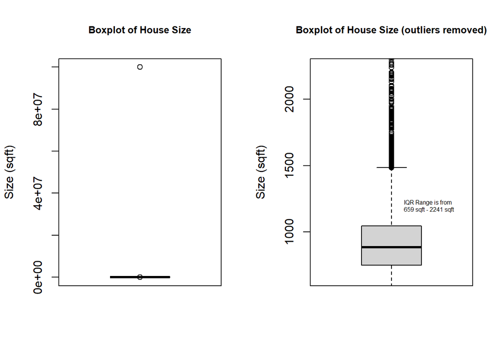

```r
par(mfrow = c(1, 2))
boxplot(rental_df$size, main = "Boxplot of House Size", ylab = "Size (sqft)", cex.main = 0.8)
boxplot(rental_df$size, main = "Boxplot of House Size (outliers removed)", ylab = "Size (sqft)", ylim = c(size_lowerlimit,size_upperlimit), cex.main = 0.8)
text(x = 1.25, y = 1200, labels = "IQR Range is from \n659 sqft - 2241 sqft", cex = 0.5)
```

Creating new dataframe after removing outliers in our numerical column: monthly rent and size.

```r
filteredrental = rental_df %>%
  filter(monthly_rent <= 2850 & size <= 2241 & monthly_rent > 100 & size > 100)

dim(filteredrental)
```

```
## [1] 18626    13
```

```r
summary(filteredrental)
```

```
##      ads_id          property_type       prop_name         completion_year
##  Min.   : 16525511   Length:18626       Length:18626       Min.   :1977
##  1st Qu.: 99850470   Class :character   Class :character   1st Qu.:2013
##  Median :100228333   Mode  :character   Mode  :character   Median :2017
##  Mean   : 99723326                                         Mean   :2015
##  3rd Qu.:100627338                                         3rd Qu.:2020
##  Max.   :100854617                                         Max.   :2025
##                                                            NA's   :8693
##   monthly_rent    district            parking          bathroom
##  Min.   : 120   Length:18626       Min.   : 1.000   Min.   :1.000
##  1st Qu.:1100   Class :character   1st Qu.: 1.000   1st Qu.:2.000
##  Median :1400   Mode  :character   Median : 1.000   Median :2.000
##  Mean   :1447                      Mean   : 1.391   Mean   :1.849
##  3rd Qu.:1750                      3rd Qu.: 2.000   3rd Qu.:2.000
##  Max.   :2850                      Max.   :10.000   Max.   :8.000
##                                    NA's   :5356     NA's   :2
##       size         furnished          facilities        additional_facilities
##  Min.   : 104.0   Length:18626       Length:18626       Length:18626
##  1st Qu.: 737.0   Class :character   Class :character   Class :character
##  Median : 867.0   Mode  :character   Mode  :character   Mode  :character
##  Mean   : 884.6
##  3rd Qu.:1012.0
##  Max.   :2238.0
##
##     region
##  Length:18626
##  Class :character
##  Mode  :character
##
##
##
##
```

#### Data Visualization

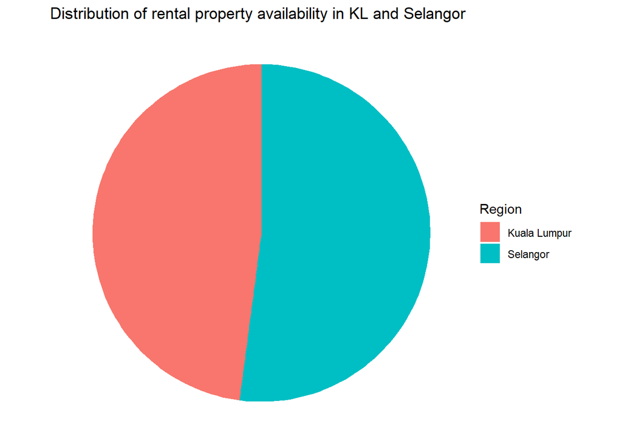

```r
ggplot(data = filteredrental, aes(x ="", fill = region)) +
  geom_bar(width = 1) +
  coord_polar("y", start = 0) +
  theme_void() +
  labs(title = "Distribution of rental property availability in KL and Selangor", fill = "Region")
```

```r
location_count = (table(rental_df$district)) %>%
  as.data.frame() %>%
  arrange(desc(Freq))
```

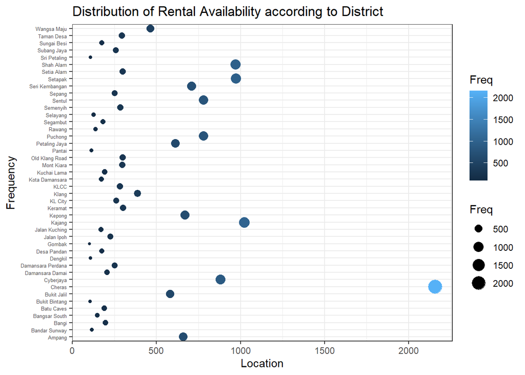

```r
location_count %>%
  filter(Freq >= 100) %>%
  ggplot(aes(x = Freq, y = Var1, size = Freq, color = Freq)) +
  geom_point() +
  labs(title = "Distribution of Rental Availability according to District", x = "Location", y = "Frequency") +
  theme_bw() +
  theme(axis.text.y = element_text(size = 5))
```

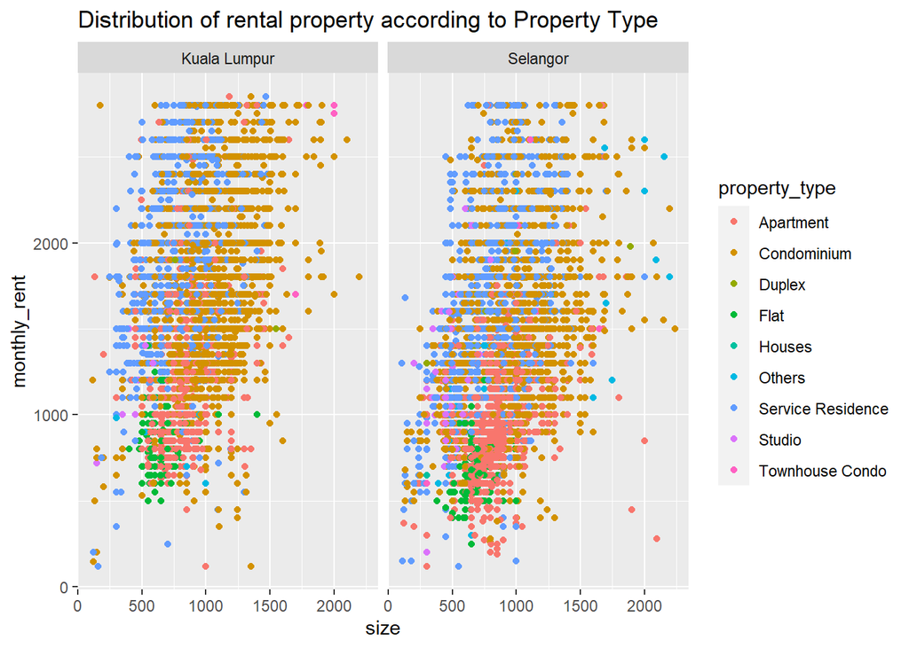

```r
ggplot (data = filteredrental) +
  geom_point(mapping = aes(x = size, y = monthly_rent, color = property_type)) +
  facet_wrap(~region) +
  labs(title = "Distribution of rental property according to Property Type")
```

```r
table(filteredrental$property_type)
```

```
##
##         Apartment       Condominium            Duplex              Flat
##              5194              7681                69               577
##            Houses            Others Service Residence            Studio
##                 1                78              4808               187
##   Townhouse Condo
##                31
```

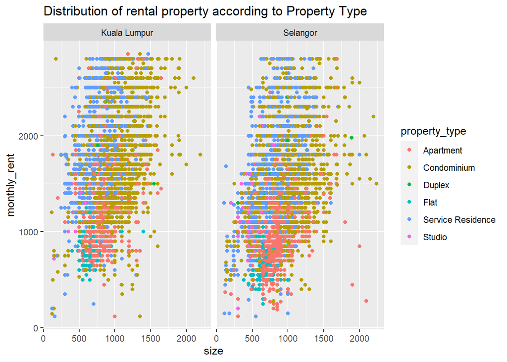

```r
apt_rental = filteredrental %>%
  filter(property_type %in%  c("Apartment", "Condominium", "Service Residence", "Flat", "Studio", "Duplex"))

ggplot (data = apt_rental) +
  geom_point(mapping = aes(x = size, y = monthly_rent, color = property_type)) +
  facet_wrap(~region) +
  labs(title = "Distribution of rental property according to Property Type")
```

### Analysing rental dependency on other variable

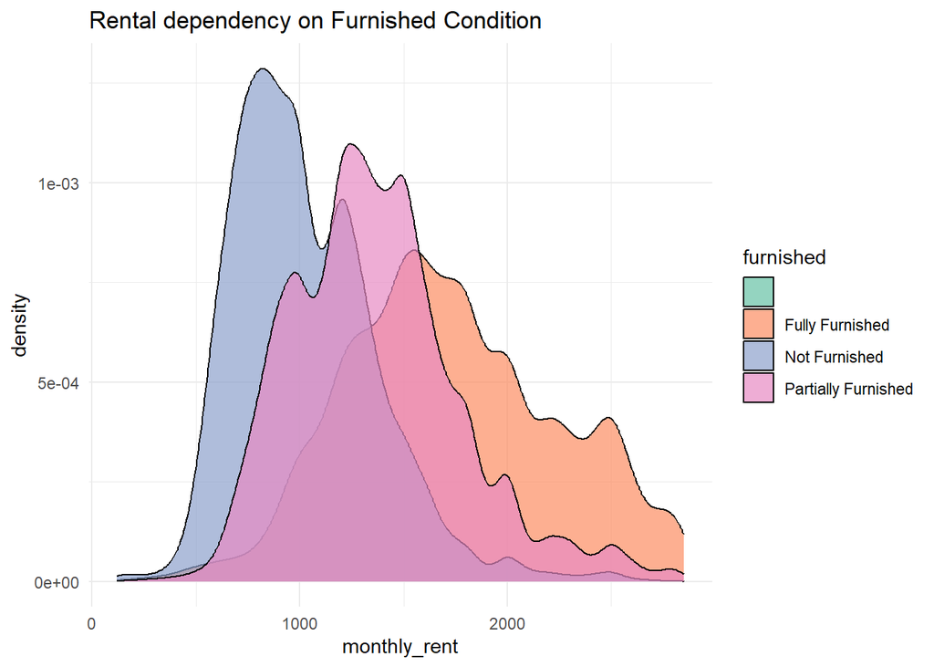

```r
ggplot(filteredrental, aes(x = monthly_rent, fill = furnished)) +
  geom_density(alpha = 0.7) +
  scale_fill_brewer(palette = "Set2") +
  labs(title = "Rental dependency on Furnished Condition") +
  theme_minimal()
```

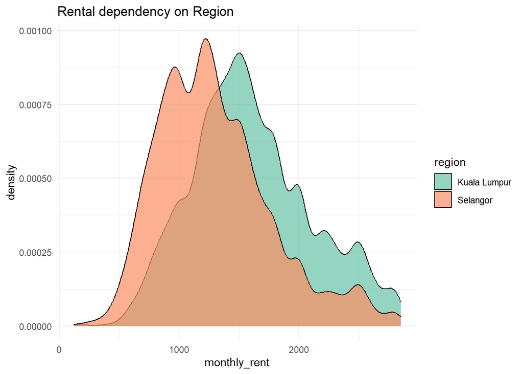

```r
ggplot(filteredrental, aes(x = monthly_rent, fill = region)) +
  geom_density(alpha = 0.7) +
  scale_fill_brewer(palette = "Set2") +
  labs(title = "Rental dependency on Region") +
  theme_minimal()
```

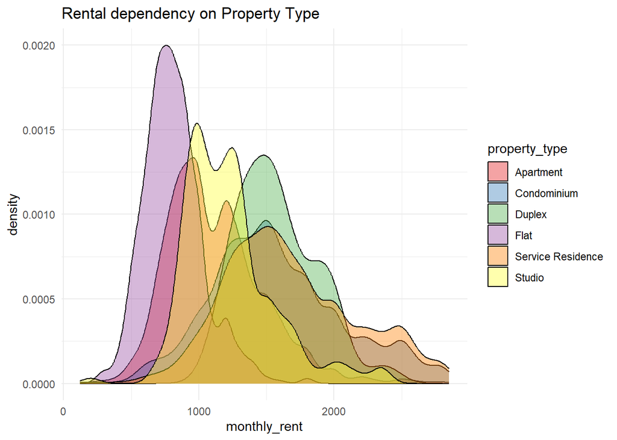

```r
ggplot(apt_rental, aes(x = monthly_rent, fill = property_type)) +
  geom_density(alpha = 0.4) +
  scale_fill_brewer(palette = "Set1") +
  labs(title = "Rental dependency on Property Type") +
  theme_minimal()
```

Extracting “Near KTM/LRT” information into a new column, added onto dataframe.

```r
rental_publictransport = filteredrental %>%
  mutate(
    public_transport = str_extract(additional_facilities, "Near KTM/LRT"),
    public_transport = replace(public_transport, is.na(public_transport), "Not Near KTM/LRT"))
```